# Problem Set 6

### Part A

Run a pooled regression model of `LnAvgSalary` on `OnCycle`. Write the estimated regression equation, and interpret the coefficient on `OnCycle.` Are there any sources of bias (consider in particular the argument in the question prompt)?

```r
pooled_reg <- lm(LnAvgSalary ~ OnCycle, data = schools)
summary(pooled_reg)
```

```
Call:
lm(formula = LnAvgSalary ~ OnCycle, data = schools)

Residuals:
     Min       1Q   Median       3Q      Max
-0.28910 -0.05527 -0.00646  0.05196  0.65215

Coefficients:
             Estimate Std. Error   t value Pr(>|t|)
(Intercept) 10.671363   0.001018 10478.815   <2e-16 ***
OnCycle     -0.030621   0.003766    -8.131    5e-16 ***
---
Signif. codes:  0 '***' 0.001 '**' 0.01 '*' 0.05 '.' 0.1 ' ' 1

Residual standard error: 0.08284 on 7137 degrees of freedom
  (64 observations deleted due to missingness)
Multiple R-squared:  0.009178,  Adjusted R-squared:  0.009039
F-statistic: 66.11 on 1 and 7137 DF,  p-value: 4.995e-16
```

$$\widehat{\text{log(Average Salary})_it} = 10.67-0.03 \, \text{OnCycle}_{it}$$

This is almost certainly biased. There are probably things correlated at the district level between both whether or not districts vote (or switch to voting) on cycle/off cycle and with teacher salaries. Perhaps some districts have strong/weak teachers unions and that determines whether they choose to vote on or off cycle (off cycle would be preferable, and perhaps districts with strong teachers unions kept the elections off cycle).

Also, there could be changes in the entire State over time-perhaps all Texas teacher salaries were increasing or decreasing over the years.

### Part B

Some schools decided to switch to an on-cycle election after 2006. Consider this, `CycleSwitch` the “treatment.” Create a variable to indicate post-treatment years (i.e. years after 2006). Call it `After`. Create a second, *interaction* variable to capture the interaction effect between those districts that *switched*, and *after* the treatment.

```r
# create a variable, that is a factor, using ifelse() function
#   if the year is greater than 2006, code "After" as 1,
#   if the year is NOT greater than 2006, code "After" as 0
schools <- schools %>%
  mutate(After = factor(ifelse(test = Year > 2006,
                        yes = 1,
                        no = 0)))
head(schools)
```

| DistNumber | Year | OnCycle | LnAvgSalary | CycleSwitch | After |
| --- | --- | --- | --- | --- | --- |
| 4800001 | 2003 | 0 | 10.63609 | 0 | 0 |
| 4800001 | 2004 | 0 | 10.60806 | 0 | 0 |
| 4800001 | 2005 | 0 | 10.58919 | 0 | 0 |
| 4800001 | 2006 | 0 | 10.61234 | 0 | 0 |
| 4800001 | 2007 | 0 | 10.60016 | 0 | 1 |
| 4800001 | 2008 | 0 | 10.58297 | 0 | 1 |

### Part C

Now estimate a difference-in-difference model with your variables in Part B: `CycleSwitch` is the treatment variable, `After` is your post-treatment indicator, and add an *interaction* variable to capture the interaction effect between those districts that *switched*, and *after* the treatment. Write down the estimated regression equation (to four decimal places).

```r
dnd <- lm(LnAvgSalary ~ CycleSwitch + After + CycleSwitch:After, data = schools)
summary(dnd)
```

```
Call:
lm(formula = LnAvgSalary ~ CycleSwitch + After + CycleSwitch:After,
    data = schools)

Residuals:
     Min       1Q   Median       3Q      Max
-0.29811 -0.05595 -0.00734  0.05284  0.65245

Coefficients:
                    Estimate Std. Error  t value Pr(>|t|)
(Intercept)        10.671068   0.001433 7447.598  < 2e-16 ***
CycleSwitch        -0.023982   0.003397   -7.059 1.83e-12 ***
After1              0.009303   0.002188    4.251 2.16e-05 ***
CycleSwitch:After1 -0.008590   0.005189   -1.655   0.0979 .
---
Signif. codes:  0 '***' 0.001 '**' 0.01 '*' 0.05 '.' 0.1 ' ' 1

Residual standard error: 0.08334 on 7198 degrees of freedom
  (1 observation deleted due to missingness)
Multiple R-squared:  0.0183,    Adjusted R-squared:  0.01789
F-statistic: 44.72 on 3 and 7198 DF,  p-value: < 2.2e-16
```

$$\widehat{\text{Log(Average Salary)}_{it}}=10.6711-0.0240 \, \text{Cycle Switch}_{i} + 0.0093 \, \text{After}_t - 0.0086 \, (\text{Cycle Switch}_i \times \text{After}_t)$$

### Part D

Interpret what each coefficient means from Part C.

- $\hat{\beta_0}$: districts before 2007 that did not switch had `ln(AvgSalary)` of 10.6711
- $\hat{\beta_1}$: districts before 2007 that did switch had `ln(AvgSalary)` 0.0240 lower than districts that did not switch
- $\hat{\beta_2}$: all districts after the change had `ln(AvgSalary)` 0.0093 higher than before the change
- $\hat{\beta_3}$: districts that made a switch had a 0.0086 *lower* change in `ln(AvgSalary)` over time than districts that did not switch

### Part E

Using your regression equation in Part C, calculate the expected logged average salary $(Y)$ for districts in Texas:

1. *Before* the switch that did *not* switch
2. *After* the switch that did *not* switch
3. *Before* the switch that *did* switch
4. *After* the switch that *did* switch
1. Before change and did not switch: $\hat{\beta_0} = 10.6711$
2. After change and did not switch: $\hat{\beta_0}+\hat{\beta_2} = 10.6711 + 0.0093 = 10.6804$
3. Before change and did switch: $\hat{\beta_0}+\hat{\beta_1} = 10.6711 − 0.0240 = 10.6471$
4. After change and did switch: $\hat{\beta_0}+\hat{\beta_1}+\hat{\beta_2}+\hat{\beta_3} = 10.6711−0.0240+ 0.0093 − 0.0086 = 10.6478$

|  | Before | After | Time Diff |
| --- | --- | --- | --- |
| Did not switch | $\hat{\beta}_0$ | $\hat{\beta}_0+\hat{\beta}_2$ | $\hat{\beta}_2$ |
| Switched | $\hat{\beta}_0 + \hat{\beta}_1$ | $\hat{\beta}_0 + \hat{\beta}_1 + \hat{\beta}_2 + \hat{\beta}_3$ | $\hat{\beta}_2 + \hat{\beta}_3$ |
| **Group Diff** | $\hat{\beta}_1$ | $\hat{\beta}_1+\hat{\beta}_3$ | $\hat{\beta}_3$ |

[output not shown]

### Part F

Confirm your estimates in Part E by finding the mean logged average salary for each of those four groups in the data. (Hint, `filter()` properly then `summarize()`.)

```r
# avg log salary for districts BEFORE that did NOT switch
schools %>%
  filter(CycleSwitch == 0,
         After == 0) %>%
  summarize(average = mean(LnAvgSalary, na.rm=T)) # need to remove NA's
```

| average |
| --- |
| 10.67107 |

```r
# avg log salary for districts AFTER that did NOT switch
schools %>%
  filter(CycleSwitch == 0,
         After == 1) %>%
  summarize(average = mean(LnAvgSalary, na.rm=T)) # need to remove NA's
```

| average |
| --- |
| 10.68037 |

```r
# avg log salary for districts BEFORE that DID switch
schools %>%
  filter(CycleSwitch == 1,
         After == 0) %>%
  summarize(average = mean(LnAvgSalary, na.rm=T)) # need to remove NA's
```

| average |
| --- |
| 10.64709 |

```r
# avg log salary for districts AFTER that DID switch
schools %>%
  filter(CycleSwitch == 1,
         After == 1) %>%
  summarize(average = mean(LnAvgSalary, na.rm=T)) # need to remove NA's
```

| average |
| --- |
| 10.6478 |

### Part G

Write out the difference-in-difference equation, and calculate the difference-in-difference. Make sure it matches your estimate from the regression.

$$\begin{align*}
\Delta \Delta ln(AvgSalary)&=(Switched_{after}-Switched_{before})-(Didn't_{after}-Didn't_{before})\\
&=(10.6478-10.6471)-(10.6804-10.6711)\\
&=(0.0007)-(0.0093)\\
&=-0.0086\\ \end{align*}$$

This is $\beta_3$.

### Part H

Can we say anything about the types of districts that switched? Can we say anything about all salaries in the districts in the years after the switch?

### Part I

Now let’s generalize the diff-in-diff model. Instead of the treatment and post-treatment dummies, use district-and year-fixed effects and the interaction term. Interpret the coefficient on the interaction term.

This is doable with the dummy variable method, but there will be a *lot* of dummies! I suggest using `feols()` from the `fixest` package.

```r
dnd_twfe_reg <- feols(LnAvgSalary ~ CycleSwitch*After | factor(DistNumber) + factor(Year),
                    data = schools)
```

```
NOTE: 1 observation removed because of NA values (LHS: 1).
```

```
The variables 'CycleSwitch' and 'After1' have been removed because of collinearity (see $collin.var).
```

```r
summary(dnd_twfe_reg)
```

```
OLS estimation, Dep. Var.: LnAvgSalary
Observations: 7,202
Fixed-effects: factor(DistNumber): 1,029,  factor(Year): 7
Standard-errors: Clustered (factor(DistNumber))
                    Estimate Std. Error t value Pr(>|t|)
CycleSwitch:After1 -0.008594   0.003936 -2.1835 0.029224 *
... 2 variables were removed because of collinearity (CycleSwitch and After1)
---
Signif. codes:  0 '***' 0.001 '**' 0.01 '*' 0.05 '.' 0.1 ' ' 1
RMSE: 0.029514     Adj. R2: 0.856129
                 Within R2: 0.003027
```

### Part J

Create a nice regression table (using `modelsummary`) for comparison of the regressions in Parts A, C, and I.

```r
modelsummary(models = list("OLS" = pooled_reg,
                           "DND" = dnd,
                           "TWFE" = dnd_twfe_reg),
             fmt = 2, # round to 2 decimals
             output = "html",
             coef_rename = c("(Intercept)" = "Constant",
                             "OnCycle" = "On Cycle",
                             "CycleSwitch" = "Switched",
                             "After1" = "After Switch",
                             "CycleSwitch:After1" = "Switched x After"),
             gof_map = list(
               list("raw" = "nobs", "clean" = "n", "fmt" = 0),
               #list("raw" = "r.squared", "clean" = "R<sup>2</sup>", "fmt" = 2),
               list("raw" = "adj.r.squared", "clean" = "Adj. R<sup>2</sup>", "fmt" = 2),
               list("raw" = "rmse", "clean" = "SER", "fmt" = 2)
             ),
             escape = FALSE,
             stars = c('*' = .1, '**' = .05, '***' = 0.01)
)
```

|  | OLS | DND | TWFE |
| --- | --- | --- | --- |
| Constant | 10.67*** | 10.67*** |  |
|  | (0.001) | (0.001) |  |
| On Cycle | −0.03*** |  |  |
|  | (0.004) |  |  |
| Switched |  | −0.02*** |  |
|  |  | (0.003) |  |
| After Switch |  | 0.009*** |  |
|  |  | (0.002) |  |
| Switched x After |  | −0.009* | −0.009** |
|  |  | (0.005) | (0.004) |
| n | 7139 | 7202 | 7202 |
| Adj. R<sup>2</sup> | 0.009 | 0.02 | 0.86 |
| SER | 0.08 | 0.08 | 0.03 |

* p < 0.1, ** p < 0.05, *** p < 0.01

## Question 6 (Instrumental Variables)

- [`RainIV.csv`](http://metricsf22.classes.ryansafner.com/files/data/RainIV.csv)

Download and read in `RainIV.csv` dataset. If you don’t want to download/upload it, you can read it in directly from the url by running this chunk:

```r
# run or edit this chunk
ivrain <- read_csv("http://metricsf22.classes.ryansafner.com/files/data/RainIV.csv")
```

Does economic growth reduce the odds of civil conflict? Consider data on 41 African countries between 1981-1999. Below are key variables (among others in the data):

| Variable | Description |
| --- | --- |
| `Internalconflict` | `=1` if civil war (<25 deaths), else `=0` |
| `LaggedGDPGrowth` | GDP Growth rate from previous year |
| `LagggedRainfallGrowth` | Change (in mm) of rain from previous year |
| `InitialGDP` | GDP per capita (1979) |
| `Democracy` | Polity II score |
| `country_name` | Country name |
| `country_code` | Three letter ISO country code |
| `year` | Year |
| `pop` | Population |
| `Mountains` | Percentage of territory that is mountainous terrain |
| `EthnicFrac` | Ethnic fractionalization index (probability two random individuals are NOT from the same ethnic group) |
| `ReligiousFrac` | Religious fractionalization index (probability two random individuals are NOT from the same religion) |

### Part A

Make a scatterplot between `Internalconflict` (as `y`) and `LaggedGDPGrowth` (as `x`), and add a regression line.

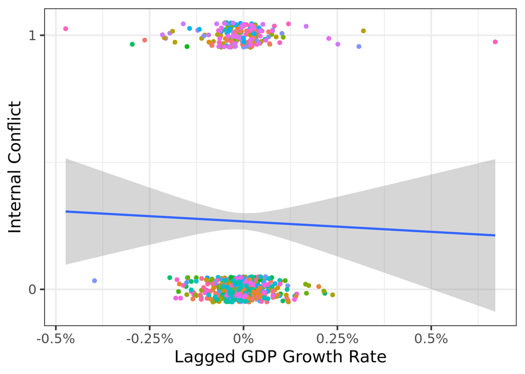

```r
ggplot(data = ivrain)+
    aes(x = LaggedGDPGrowth,
        y = InternalConflict)+
    geom_jitter(aes(color = as.factor(country_name)), height=0.05)+
    geom_smooth(method = "lm")+
  scale_x_continuous(labels = function(x){paste(x,"%", sep="")})+
  scale_y_continuous(breaks = c(0,1))+
  labs(x = "Lagged GDP Growth Rate",
       y = "Internal Conflict")+
  theme_bw(base_family = "Fira Sans Condensed",
           base_size=16)+
  theme(legend.position = "none") # remove legend for State colors
```

### Part B

Run a regression of Internalconflict`on`LaggedGDPGrowth.` Note that since $Y$ is a dummy variable, $\beta_1$ is the probability of internal conflict in country $i$ at time $t$. Write out the estimated regression equation and interpret the marginal effect.

```r
conflict_reg <- lm(InternalConflict ~ LaggedGDPGrowth, data = ivrain)
summary(conflict_reg)
```

```
Call:
lm(formula = InternalConflict ~ LaggedGDPGrowth, data = ivrain)

Residuals:
    Min      1Q  Median      3Q     Max
-0.2999 -0.2689 -0.2660  0.7228  0.7876

Coefficients:
                Estimate Std. Error t value Pr(>|t|)
(Intercept)      0.26738    0.01631  16.389   <2e-16 ***
LaggedGDPGrowth -0.08206    0.22485  -0.365    0.715
---
Signif. codes:  0 '***' 0.001 '**' 0.01 '*' 0.05 '.' 0.1 ' ' 1

Residual standard error: 0.4434 on 741 degrees of freedom
Multiple R-squared:  0.0001797, Adjusted R-squared:  -0.00117
F-statistic: 0.1332 on 1 and 741 DF,  p-value: 0.7152
```

$$\widehat{\text{Internal Conflict}_{it}} = 0.2674 - 0.0821 \, \text{Lagged GDP Growth}_{it}$$

For every additional 1% of GDP growth per capita from the previous year, the probability of internal conflict decreases by 0.08 (8%).

### Part C

Run another regression, adding in `LaggedGDPGrowth`, `InitialGDP`, `Democracy`, `Mountains` `EthnicFrac`, and `ReligiousFrac` as controls. Write out the estimated regression equation. What happens to the marginal effect of `LaggedGDPGrowth`?

```r
conflict_reg_controls <- lm(InternalConflict ~ LaggedGDPGrowth + InitialGDP + Democracy + Mountains + EthnicFrac + ReligiousFrac, data = ivrain)
summary(conflict_reg_controls)
```

```
Call:
lm(formula = InternalConflict ~ LaggedGDPGrowth + InitialGDP +
    Democracy + Mountains + EthnicFrac + ReligiousFrac, data = ivrain)

Residuals:
    Min      1Q  Median      3Q     Max
-0.5654 -0.2811 -0.2221  0.4570  0.9459

Coefficients:
                  Estimate Std. Error t value Pr(>|t|)
(Intercept)      0.0703555  0.0731012   0.962  0.33614
LaggedGDPGrowth -0.1087977  0.2200999  -0.494  0.62123
InitialGDP      -0.0569091  0.0182258  -3.122  0.00186 **
Democracy        0.0012242  0.0028894   0.424  0.67193
Mountains        0.0038654  0.0009527   4.057 5.49e-05 ***
EthnicFrac       0.3247931  0.0918181   3.537  0.00043 ***
ReligiousFrac    0.0105162  0.0958907   0.110  0.91270
---
Signif. codes:  0 '***' 0.001 '**' 0.01 '*' 0.05 '.' 0.1 ' ' 1

Residual standard error: 0.4334 on 736 degrees of freedom
Multiple R-squared:  0.05106,   Adjusted R-squared:  0.04332
F-statistic:   6.6 on 6 and 736 DF,  p-value: 8.276e-07
```

$$\begin{align*}
\widehat{\text{Internal Conflict}_{it}} = & \, 0.0704 - 0.1088 \, \text{Lagged GDP Growth}_{it} - 0.0569 \, \text{Initial GDP}_it + 0.0012 \, \text{Democracy}_{it} +\\
& 0.0039 \, \text{Mountains}_{it} + 0.3248 \, \text{Ethnic Fractionalization}_{it} + 0.0105 \, \text{Religious Fractionalization}_{it} \\ \end{align*}$$

The marginal effect of `LaggedGDPGrowth` increases from -0.0821 to -0.1088.

### Part D

Now let’s consider `LaggedRainfallGrowth` as a potential instrument for `LaggedGDPGrowth`. First, check the correlations between `InternalConflict`, `LaggedGDPGrowth` and `LaggedRainfallGrowth`.

```r
ivrain %>%
select(InternalConflict, LaggedGDPGrowth, LaggedRainfallGrowth) %>%
cor()
```

```
                     InternalConflict LaggedGDPGrowth LaggedRainfallGrowth
InternalConflict            1.0000000      -0.0134064           -0.0506118
LaggedGDPGrowth            -0.0134064       1.0000000            0.1263399
LaggedRainfallGrowth       -0.0506118       0.1263399            1.0000000
```

### Part E

Now let’s consider if `LaggedRainfallGrowth` is a **relevant** instrument (the “inclusion condition”) by running the *first stage* regression of `LaggedGDPGrowth` on `LaggedRainfallGrowth` and the rest of the controls from part C. Is the OLS estimate on `LaggedRainfallGrowth` statistically significant?

```r
first_stage <- lm(LaggedGDPGrowth ~ LaggedRainfallGrowth + InitialGDP + Democracy + Mountains + EthnicFrac + ReligiousFrac,
                 data = ivrain)
summary(first_stage)
```

```
Call:
lm(formula = LaggedGDPGrowth ~ LaggedRainfallGrowth + InitialGDP +
    Democracy + Mountains + EthnicFrac + ReligiousFrac, data = ivrain)

Residuals:
     Min       1Q   Median       3Q      Max
-0.46563 -0.03051  0.00459  0.03159  0.66704

Coefficients:
                       Estimate Std. Error t value Pr(>|t|)
(Intercept)          -0.0058041  0.0121558  -0.477 0.633168
LaggedRainfallGrowth  0.0439770  0.0128127   3.432 0.000632 ***
InitialGDP           -0.0008056  0.0030287  -0.266 0.790327
Democracy             0.0005373  0.0004798   1.120 0.263080
Mountains             0.0001087  0.0001582   0.687 0.492435
EthnicFrac            0.0031603  0.0152584   0.207 0.835976
ReligiousFrac        -0.0017176  0.0159357  -0.108 0.914197
---
Signif. codes:  0 '***' 0.001 '**' 0.01 '*' 0.05 '.' 0.1 ' ' 1

Residual standard error: 0.07201 on 736 degrees of freedom
Multiple R-squared:  0.01844,   Adjusted R-squared:  0.01044
F-statistic: 2.305 on 6 and 736 DF,  p-value: 0.0327
```

Yes, `LaggedRainfallGrowth` is statistically significant (since the p-value is much smaller than 0.05), implying the instrument is relevant. Each additional 1mm increase in rainfall from the previous year increases GDP growth rates by 0.04 percentage points.

### Part F

There is no statistical test for whether `LaggedRainfallGrowth` is exogenous (the “exclusion condition”). Do you think it is plausible that `LaggedRainfallGrowth` is uncorrelated with the error term; that is, with any other factors that cause conflict; and that it **only** affects conflict through economic growth?

Rainfall and weather certainly affects crop yields, which may be a large part of the economy in these countries, so this would certainly be a channel by which it affects conflict. Can we concieve of rainfall affecting *other* things that affect whether a country is experiencing internal conflict?

### Part G

Extract and save the fitted values of your first stage regression from part E. Now run the *second stage* regression by using the fitted values of `LaggedGDPGrowth` and the control variables from parts C and E. What is the marginal effect of `LaggedGDPGrowth` on `InternalConflict`?

```r
# add fitted values from firststage regression to the ivrain data as a column called "laggdpgrowth_hat"
ivrain$laggdpgrowth_hat <- first_stage$fitted.values

second_stage <- lm(InternalConflict ~ laggdpgrowth_hat + InitialGDP + Democracy + Mountains + EthnicFrac + ReligiousFrac, data = ivrain)
summary(second_stage)
```

```
Call:
lm(formula = InternalConflict ~ laggdpgrowth_hat + InitialGDP +
    Democracy + Mountains + EthnicFrac + ReligiousFrac, data = ivrain)

Residuals:
    Min      1Q  Median      3Q     Max
-0.5653 -0.2830 -0.2237  0.4748  0.9952

Coefficients:
                   Estimate Std. Error t value Pr(>|t|)
(Intercept)       0.0625061  0.0733775   0.852 0.394579
laggdpgrowth_hat -2.0631528  1.7522115  -1.177 0.239394
InitialGDP       -0.0580798  0.0182415  -3.184 0.001514 **
Democracy         0.0023613  0.0030592   0.772 0.440438
Mountains         0.0040694  0.0009691   4.199 3.01e-05 ***
EthnicFrac        0.3288508  0.0918180   3.582 0.000364 ***
ReligiousFrac     0.0047242  0.0959548   0.049 0.960746
---
Signif. codes:  0 '***' 0.001 '**' 0.01 '*' 0.05 '.' 0.1 ' ' 1

Residual standard error: 0.4331 on 736 degrees of freedom
Multiple R-squared:  0.05253,   Adjusted R-squared:  0.04481
F-statistic: 6.801 on 6 and 736 DF,  p-value: 4.937e-07
```

### Part H

Now run the same regression using `feols()` from the `fixest` package.

```r
tsls <- feols(InternalConflict ~ InitialGDP + Democracy + Mountains + EthnicFrac + ReligiousFrac | LaggedGDPGrowth ~ LaggedRainfallGrowth,
           data = ivrain)
summary(tsls)
```

```
TSLS estimation, Dep. Var.: InternalConflict, Endo.: LaggedGDPGrowth, Instr.: LaggedRainfallGrowth
Second stage: Dep. Var.: InternalConflict
Observations: 743
Standard-errors: IID
                     Estimate Std. Error   t value   Pr(>|t|)
(Intercept)          0.062506   0.077268  0.808955 0.41880232
fit_LaggedGDPGrowth -2.063153   1.845106 -1.118176 0.26385684
InitialGDP          -0.058080   0.019209 -3.023646 0.00258426 **
Democracy            0.002361   0.003221  0.733011 0.46378490
Mountains            0.004069   0.001020  3.987785 0.00007335 ***
EthnicFrac           0.328851   0.096686  3.401233 0.00070705 ***
ReligiousFrac        0.004724   0.101042  0.046755 0.96272101
---
Signif. codes:  0 '***' 0.001 '**' 0.01 '*' 0.05 '.' 0.1 ' ' 1
RMSE: 0.453894   Adj. R2: -0.059159
F-test (1st stage), LaggedGDPGrowth: stat = 11.8    , p = 6.32e-4 , on 1 and 736 DoF.
                         Wu-Hausman: stat =  1.26244, p = 0.261556, on 1 and 735 DoF.
```

### Part I

Make a nice regression table using `modelsummary()` using your results from Parts B, G, and H.

```r
modelsummary(models = list("OLS" = conflict_reg,
                           "2SLS" = second_stage,
                           "2SLS (fixest)" = tsls),
             fmt = 2, # round to 2 decimals
             output = "html",
             coef_rename = c("(Intercept)" = "Constant",
                             "LaggedGDPGrowth" = "Lag GDP Growth Rate",
                             "laggdpgrowth_hat" = "Lag GDP Growth Rate",
                             "fit_LaggedGDPGrowth" = "Lag GDP Growth Rate"),
             gof_map = list(
               list("raw" = "nobs", "clean" = "n", "fmt" = 0),
               #list("raw" = "r.squared", "clean" = "R<sup>2</sup>", "fmt" = 2),
               list("raw" = "adj.r.squared", "clean" = "Adj. R<sup>2</sup>", "fmt" = 2),
               list("raw" = "rmse", "clean" = "SER", "fmt" = 2)
             ),
             escape = FALSE,
             stars = c('*' = .1, '**' = .05, '***' = 0.01)
)
```

|  | OLS | 2SLS | 2SLS (fixest) |
| --- | --- | --- | --- |
| Constant | 0.27*** | 0.06 | 0.06 |
|  | (0.02) | (0.07) | (0.08) |
| Lag GDP Growth Rate | −0.08 | −2.06 | −2.06 |
|  | (0.22) | (1.75) | (1.85) |
| InitialGDP |  | −0.06*** | −0.06*** |
|  |  | (0.02) | (0.02) |
| Democracy |  | 0.002 | 0.002 |
|  |  | (0.003) | (0.003) |
| Mountains |  | 0.004*** | 0.004*** |
|  |  | (0.001) | (0.001) |
| EthnicFrac |  | 0.33*** | 0.33*** |
|  |  | (0.09) | (0.10) |
| ReligiousFrac |  | 0.005 | 0.005 |
|  |  | (0.10) | (0.10) |
| n | 743 | 743 | 743 |
| Adj. R<sup>2</sup> | −0.001 | 0.04 | −0.06 |
| SER | 0.44 | 0.43 | 0.45 |

* p < 0.1, ** p < 0.05, *** p < 0.01

## Footnotes

[^1]: It’s better to use the `plm()`-generated regressions so as to avoid the multitude of coefficients for the state and year dummies! You certainly could use the dummy variable ones and manually list all of the variables to suppress in the table inside `omit_coefs()`…